# PML_Assignment

Matteo Zucchetta

Saturday, May 23, 2015

After a little preprocessing of the dataset, in order to fix some of the problems in the data, the most relevant information will be used as predictors for a ML algorithm, after data transformation (pca-based, performed on train data).

# Data Processing.

The dataset is loaded into R using the *read.csv* function.

```r
library(caret)
data_train <- read.csv("pml-training.csv")

data_test<- read.csv("pml-testing.csv")
```

The characteristics of the dataset are analyses with the *summary* function (not shown, see code).

```r
summary(data_train)
```

```r
set.seed(3452)

inTrain <- createDataPartition(data_train$classe, p = 1/10, list = FALSE)
tr_df <-  data_train[inTrain, ]
test_df <-  data_train[-inTrain, ]

whichNA <- ifelse(unlist(lapply(1:ncol(tr_df),function(x) length(which(is.na(tr_df[, x]))))) / nrow(tr_df) > 0.1, 0, 1)

tr_df <- tr_df[, which(whichNA == 1)]
test_df <- test_df[, which(whichNA == 1)]

whichEMPTY <- ifelse(unlist(lapply(1:ncol(tr_df),function(x) length(which(tr_df[, x] == "")))) / nrow(tr_df) > 0.1, 0, 1)

tr_df <- tr_df[, which(whichEMPTY == 1)]
test_df <- test_df[, which(whichEMPTY == 1)]

nzv <- nearZeroVar(tr_df[, c(8:59)], saveMetrics = T)
which(nzv$zeroVar) # non problem!
```

```
## integer(0)
```

Data is checked for correlations:

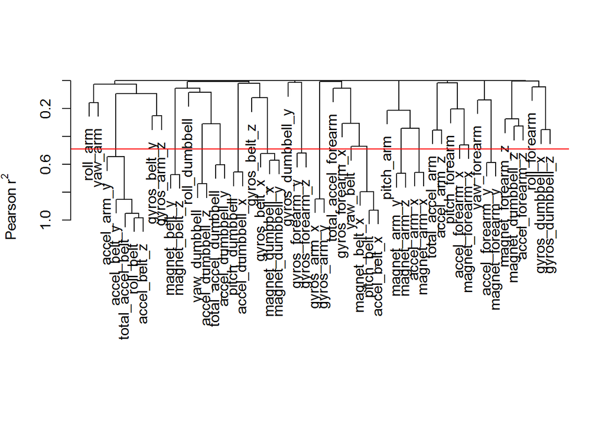

```r
library(Hmisc)
clus<-varclus(as.matrix(tr_df[, -c(1:7, 60)]), similarity=c("pearson"), type=c("data.matrix"))
plot(clus,ylim=c(0,0.8));abline(h=1-0.7^2,col="red")#;abline(h=1-0.95^2,col="red",lty=3)
```

Many retained variables are highly correlated, so the are pre-processed with a PCA, keeping the number of PCs needed to explain 95% of the variance.

```r
preProc<- preProcess(tr_df[, -c(1:7, 60)], method = "pca", thresh = 0.95)
preProcVal <- predict(preProc, tr_df[, -c(1:7, 60)])
print(paste('n° PCs =', ncol(preProcVal)))
```

```
## [1] "n° PCs = 26"
```

# Model Fitting

A Random Forest is trained, along with a single tree model, just for comparison. The two algorithm are fitted after the exploration of the optimal values of the training parameters (*mtry* and *cp*), by means of a 5-fold Cross Validation performed on the training set, to obtain an estimation of the accuracy of the classification.

```r
trl <- trainControl(classProbs=TRUE, repeats = 5, method = "cv", number = 5)

grid_rf <- expand.grid(.mtry = c(3:12)) # model selection parameter in this case mtry.
grid_rpart<- expand.grid(.cp = c(0.01, 0.05,  0.1, 0.2, 0.5, 0.8, 0.99)) # model selection parameter in this case cp

ntr <- 2000 # number of trees of the RF

# Both trainControl and expand.grid is provided by caret
set.seed(89)
mod_rf <- train(x = preProcVal, y = tr_df[, 60], method = "rf", tuneGrid=grid_rf, metric = c("Kappa"), trControl = trl, ntree = ntr)

mod_rf
```

```
## Random Forest
##
## 1964 samples
##   26 predictor
##    5 classes: 'A', 'B', 'C', 'D', 'E'
##
## No pre-processing
## Resampling: Cross-Validated (5 fold)
##
## Summary of sample sizes: 1572, 1572, 1570, 1570, 1572
##
## Resampling results across tuning parameters:
##
##   mtry  Accuracy  Kappa  Accuracy SD  Kappa SD
##    3    0.844     0.802  0.0164       0.0209
##    4    0.837     0.794  0.0223       0.0283
##    5    0.837     0.793  0.0268       0.0341
##    6    0.837     0.793  0.0177       0.0225
##    7    0.835     0.791  0.0208       0.0265
##    8    0.833     0.789  0.0205       0.0260
##    9    0.830     0.785  0.0212       0.0270
##   10    0.824     0.778  0.0223       0.0284
##   11    0.828     0.782  0.0241       0.0307
##   12    0.828     0.782  0.0266       0.0338
##
## Kappa was used to select the optimal model using  the largest value.
## The final value used for the model was mtry = 3.
```

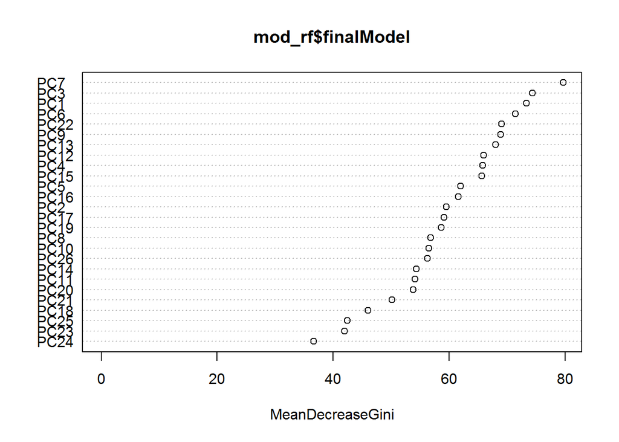

```r
varImpPlot(mod_rf$finalModel)
```

```r
mod_rpart <- train(x = preProcVal, y = tr_df[, 60], method = "rpart", tuneGrid=grid_rpart, metric = c("Kappa"), trControl = trl)
mod_rpart
```

```
## CART
##
## 1964 samples
##   26 predictor
##    5 classes: 'A', 'B', 'C', 'D', 'E'
##
## No pre-processing
## Resampling: Cross-Validated (5 fold)
##
## Summary of sample sizes: 1572, 1571, 1571, 1571, 1571
##
## Resampling results across tuning parameters:
##
##   cp    Accuracy  Kappa   Accuracy SD  Kappa SD
##   0.01  0.486     0.3460  0.02800      0.0333
##   0.05  0.316     0.0652  0.02977      0.0597
##   0.10  0.284     0.0000  0.00122      0.0000
##   0.20  0.284     0.0000  0.00122      0.0000
##   0.50  0.284     0.0000  0.00122      0.0000
##   0.80  0.284     0.0000  0.00122      0.0000
##   0.99  0.284     0.0000  0.00122      0.0000
##
## Kappa was used to select the optimal model using  the largest value.
## The final value used for the model was cp = 0.01.
```

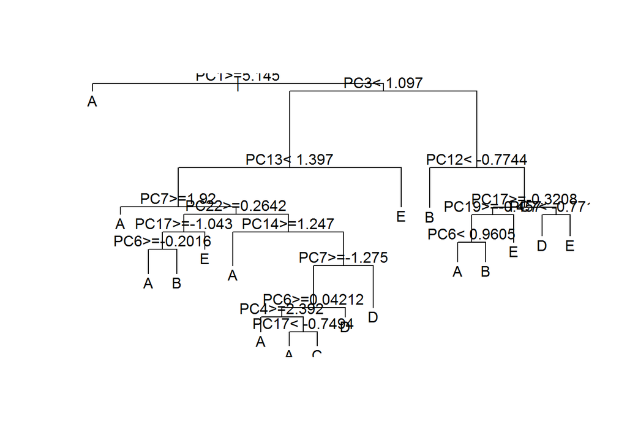

```r
plot(mod_rpart$finalModel)
text(mod_rpart$finalModel)
```

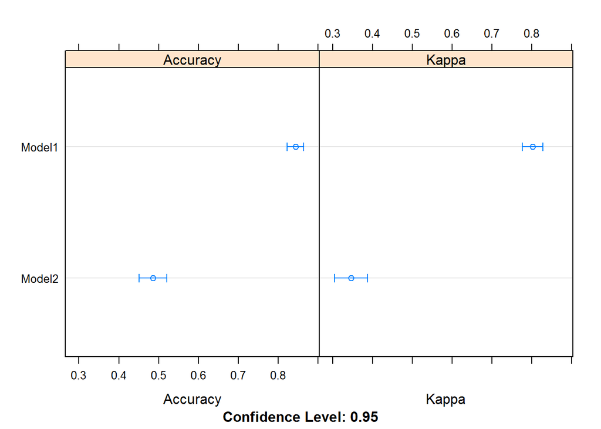

```r
results <- resamples(list(mod_rf, mod_rpart))

dotplot(results)
```

# Accuracy

The estimated accuracy (by mean of CV) is **0.49** for the single tree (rpart) and **0.84** for the Random Forest model. This is the expected out of bag accuracy. The data not used for training the model can be used to obtain a more robust accuracy estimation.

```r
test_set <- predict(preProc, newdata = test_df[, -c(1:7, 60)])
cm <- confusionMatrix(predict(mod_rf, newdata = test_set), test_df$classe)
print(cm)
```

```
## Confusion Matrix and Statistics
##
##           Reference
## Prediction    A    B    C    D    E
##          A 4705  275  103   62   45
##          B  106 2684  232   80  251
##          C   76  316 2569  281  154
##          D  118   49  111 2408  105
##          E   17   93   64   63 2691
##
## Overall Statistics
##
##                Accuracy : 0.8527
##                  95% CI : (0.8474, 0.8579)
##     No Information Rate : 0.2844
##     P-Value [Acc > NIR] : < 2.2e-16
##
##                   Kappa : 0.8135
##  Mcnemar's Test P-Value : < 2.2e-16
##
## Statistics by Class:
##
##                      Class: A Class: B Class: C Class: D Class: E
## Sensitivity            0.9369   0.7855   0.8344   0.8321   0.8290
## Specificity            0.9616   0.9530   0.9433   0.9741   0.9836
## Pos Pred Value         0.9066   0.8005   0.7565   0.8628   0.9191
## Neg Pred Value         0.9746   0.9488   0.9642   0.9673   0.9623
## Prevalence             0.2844   0.1935   0.1744   0.1639   0.1838
## Detection Rate         0.2665   0.1520   0.1455   0.1364   0.1524
## Detection Prevalence   0.2939   0.1899   0.1923   0.1581   0.1658
## Balanced Accuracy      0.9492   0.8693   0.8888   0.9031   0.9063
```

The accuracy of classification, according to the testing set of data is: **0.85**. Finally, the prediction of the Random Forest model for the 20 observation left out for the evaluation, are given in the next chunk.

```r
out_test <- data_test[, which(whichNA == 1)]
out_test <- out_test[, which(whichEMPTY == 1)]

out_proc <- predict(preProc, newdata = out_test[, -c(1:7, 60)])

table(out_test$problem_id,predict(mod_rf, newdata = out_proc))
```

```
##
##      A B C D E
##   1  1 0 0 0 0
##   2  1 0 0 0 0
##   3  1 0 0 0 0
##   4  1 0 0 0 0
##   5  1 0 0 0 0
##   6  0 0 0 0 1
##   7  0 0 0 1 0
##   8  0 1 0 0 0
##   9  1 0 0 0 0
##   10 1 0 0 0 0
##   11 1 0 0 0 0
##   12 0 0 1 0 0
##   13 0 1 0 0 0
##   14 1 0 0 0 0
##   15 0 0 0 0 1
##   16 0 0 0 0 1
##   17 1 0 0 0 0
##   18 0 1 0 0 0
##   19 0 1 0 0 0
##   20 0 1 0 0 0
```